# Supervised Learning

## 지도학습

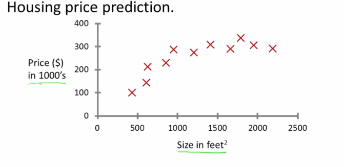

누군가가 750 제곱 피트 짜리 집을 보유 하고 있고, 그집 을 판매하려 하며, 얼마에 팔수 있을지 알고 싶다면 어떻게 하면 될까 ?

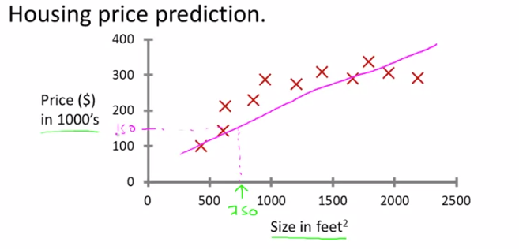

그래프에서 데이터를 통과 하는 직선(일차 함수)을 그리고 그에 맞게 가격을 예측 해볼 수 있다.

집을 15만 달러 정도에 팔 수 있을 것으로 예상된다.  
다른 방법으로는 곡선(이차 함수) 에 맞게 그래프를 그려볼 수 있다.

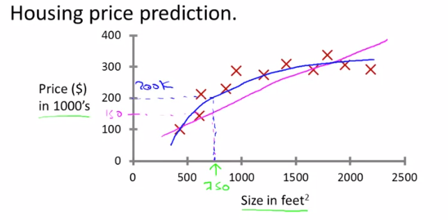

2차 함수에 맞추면 20만 달러 정도에 집을 판매 할 수 있다. 우리는 여기서 일차함수에 맞게 가격을 측정 할 것인지 아니면 2차함수에 맞게 가격을 측정할 것인지 판단해야 한다 .

이것들이 지도학습 알고리즘의 예시이다

**지도학습이란 우리가 알고리즘에게 데이터를 제공하는데 그 데이터에 '정답' 이 포함되어 있는 것이다.**

그리고 위와 같이 정답이 실수형인 경우를 **회귀** 라고한다.

다른 종류의 지도 학습에 대해 알아보자. 어떤 사람의 종양이 악성인지 양성인지 판단하는 경우를 살펴보자.

수집 된 데이터를 살펴보자 수집된 데이터의 가로축은 종양의 크기이고 세로축은 악성(1)/양성(0)의 종류이다.

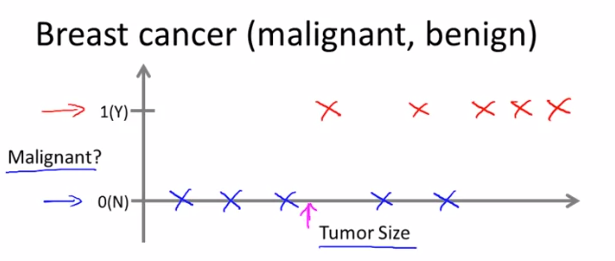

불행히도 어떤 친구가 종양이 있는데 종양의 크기가 그래프 에서 보라색 위치 라면 이 종양이 양성인지 음성인지 예상 할 수 있을까 ?

이러한 지도 학습의 경우를 **분류** 라고 한다. 위 문제에서는 정답이 2개( 양성 / 악성 ) 였지만 정답이 여러개 인 경우도 상관없다. 그리고 피처의 값도 한개인 경우이고 마찬가지로 피처의 개수도 여러개 가 될 수있다.

분류와 회귀의 다른점은 분류는 정답 데이터가 이산형이란 것이다.

피처가 2개인 데이터에 대해서 시각화 하면 아래와 같다.

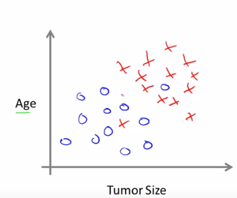

다음 과 같은 데이터가 주어졌을데 알고리즘은 아래와 같이 선을 그어서 양성과 음성을 분리 해 낼 수 있다.

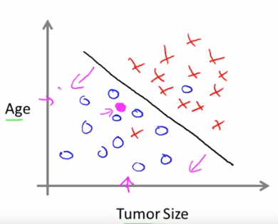

그러면 우리가 예측하고 싶은 데이터(보라색)는 양성 데이터 쪽에 속하므로 종양이 양성이라고 예측 할 수 있다.

### 요약

이번 강의 에서는 지도 학습에 대해 알아 보았는데, 지도학습은 우리가 학습시킬 데이터에 예측해 줬으면 하는 정답을 포함시켜 알고리즘을 학습시키는 것이다. 그리고 지도 학습에는 크게 회귀와 분류 가 있는데 회귀는 연속적인 정답 값에 대해 예측하는 것이고 분류는 이산적인 정답 값에 대해 예측하는 것이다.